# Practical 7: Text Mining 1

Author

Ward B. Eiling

# Introduction

In this practical, we are going to use the following packages to create document-term matrices on BBC news data set and apply LDA topic modeling.

```r
library(here)
library(tidyverse)
library(tidytext)
library(tm)
library(e1071)
library(topicmodels)
library(stringi)
```

# Take-home exercises

## Vector space model: document-term matrix

The data set used in this practical is the BBC News data set. You can use the provided [“news_dataset.rda”](https://infomda2.nl/practicals/08_text_mining/data/news_dataset.rda) for this purpose. The raw data set can also be downloaded from [here](http://mlg.ucd.ie/datasets/bbc.html).

This data set consists of 2225 documents from the BBC news website corresponding to stories in five topical areas from 2004 to 2005. These areas are:

- Business
- Entertainment
- Politics
- Sport
- Tech

**1. Use the code below to load the data set and inspect its first rows.**

```r
load(here("practical_07_text-mining/news_dataset.rda"))
head(df_final)
```

```
  File_Name
1   001.txt
2   002.txt
3   003.txt
4   004.txt
5   005.txt
6   006.txt
                                                                                                                                                                                                                                                                                                            …
1 Ad sales boost Time Warner profit\n\nQuarterly profits at US media giant TimeWarner jumped 76% to $1.13bn (£600m) for the three months to December, from $639m year-earlier.\n\nThe firm, which is now one of the biggest investors in Google, benefited from sales of high-speed internet connections and…
2                                                                                                                                                                                                                                                                                                           …
3                                                                                                                                                                                                                                                                                                           …
4                                                                                                                                                               High fuel prices hit BA's profits\n\nBritish Airways has blamed high fuel prices for a 40% drop in profits.\n\nReporting its results for the…
5                                                                                                                                                                                                                                                                                                           …
6                                                                                                                                                                                                                                                                                                           …
  Category Complete_Filename
1 business  001.txt-business
2 business  002.txt-business
3 business  003.txt-business
4 business  004.txt-business
5 business  005.txt-business
6 business  006.txt-business
```

**2. Find out about the name of the categories and the number of observations in each of them.**

```r
str(df_final)
```

```
'data.frame':   2225 obs. of  4 variables:
 $ File_Name        : chr  "001.txt" "002.txt" "003.txt" "004.txt" ...
 $ Content          : chr  "Ad sales boost Time Warner profit\n\nQuarterly profits at US media giant TimeWarner jumped 76% to $1.13bn (£600"| __truncated__ "Dollar gains on Greenspan speech\n\nThe dollar has hit its highest level against the euro in almost three month"| __truncated__ "Yukos unit buy…
 $ Category         : chr  "business" "business" "business" "business" ...
 $ Complete_Filename: chr  "001.txt-business" "002.txt-business" "003.txt-business" "004.txt-business" ...
```

```r
table(as.factor(df_final$Category))
```

```
     business entertainment      politics         sport          tech
          510           386           417           511           401
```

**3. Convert the data set into a document-term matrix and use the `findFreqTerms` function to keep the terms which their frequency is higher than 10. It is also a good idea to apply some text preprocessing before this conversion: e.g., remove non-UTF-8 characters, convert the words into lowercase, remove punctuation, numbers, stopwords, and whitespaces.**

```r
controls <- list(tolower = TRUE,
                 removePunctuation = TRUE,
                 removeNumbers = TRUE,
                 stopwords = TRUE,
                 removeWords = stopwords("en"),
                 stripWhitespace = TRUE)

dtm <- Corpus(VectorSource(df_final$Content)) %>%
  tm_map(iconv, from = "UTF-8", to = "UTF-8", sub = '') %>%
  DocumentTermMatrix(control = controls)

freq_terms <- findFreqTerms(dtm, 10)
head(freq_terms)
```

```
[1] "accounts"    "advert"      "advertising" "alexander"   "already"
[6] "also"
```

**4. Partition the original data into training and test sets with 80% for training and 20% for test.**

```r
set.seed(123)
train_index <- sample(1:nrow(df_final), 0.8 * nrow(df_final))
train <- df_final[train_index,]
test <- df_final[-train_index,]
```

**5. Create separate document-term matrices for the training and the test sets using the previous frequent terms as the input dictionary and convert them into data frames.**

```r
train_dtm <- dtm[train_index, colnames(dtm) %in% freq_terms]
train_dtm_df <- as.data.frame(as.matrix(train_dtm))
test_dtm <- dtm[-train_index, colnames(dtm) %in% freq_terms]
test_dtm_df <- as.data.frame(as.matrix(test_dtm))
```

**6. OPTIONAL: Use the cbind function to add the categories to the train_dtm data and name the column y.**

```r
train_dtm_y <- cbind(y = as.factor(train$Category), train_dtm_df)
test_dtm_y <- cbind(y = as.factor(test$Category), test_dtm_df)
```

**7. OPTIONAL: Fit a SVM model with a linear kernel on the training data set. Predict the categories for the training and test data.**

```r
svm_model <- svm(y ~ ., data = train_dtm_y, kernel = "linear")
summary(svm_model)
```

```
Call:
svm(formula = y ~ ., data = train_dtm_y, kernel = "linear")


Parameters:
   SVM-Type:  C-classification
 SVM-Kernel:  linear
       cost:  1

Number of Support Vectors:  855

 ( 179 210 123 150 193 )


Number of Classes:  5

Levels:
 business entertainment politics sport tech
```

```r
pred_svm_train <- predict(svm_model, train_dtm_y)
(confus_train <- table(pred = pred_svm_train, true = train_dtm_y$y))
```

```
               true
pred            business entertainment politics sport tech
  business           409             0        0     0    0
  entertainment        0           318        0     0    0
  politics             0             0      337     0    0
  sport                0             0        0   396    0
  tech                 0             0        0     0  320
```

```r
sum(diag(confus_train)) / sum(confus_train)
```

```
[1] 1
```

```r
pred_svm_train <- predict(svm_model, test_dtm_y)
(confus_test <- table(pred = pred_svm_train, true = test_dtm_y$y))
```

```
               true
pred            business entertainment politics sport tech
  business            96             2        3     0    0
  entertainment        2            64        0     0    0
  politics             3             2       76     0    0
  sport                0             0        1   115    0
  tech                 0             0        0     0   81
```

```r
sum(diag(confus_test)) / sum(confus_test)
```

```
[1] 0.9707865
```

We obtain a predictive accuracy of 100% on the training set and 97.1% on the test set.

# Lab exercises

## Topic modeling

Latent Dirichlet allocation (LDA) is a particularly popular method for fitting a topic model. It treats each document as a mixture of topics, and each topic as a mixture of words. This allows documents to “overlap” each other in terms of content, rather than being separated into discrete groups, in a way that mirrors typical use of natural language.

**8. Use the LDA function from the `topicmodels` package to train an LDA model with 5 topics with the Gibbs sampling method.**

```r
lda_model <- LDA(train_dtm_df, k = 5, method = "Gibbs", control = list(seed = 123))
lda_model
```

```
A LDA_Gibbs topic model with 5 topics.
```

**9. The `tidy()` method is originally from the `broom` package (Robinson 2017), for tidying model objects. The `tidytext` package provides this method for extracting the per-topic-per-word probabilities, called “beta”, from the LDA model. Use this function and check the beta probabilites for each term and topic.**

```r
lda_topics <- tidy(lda_model, matrix = "beta")
head(lda_topics, 10)
```

```
# A tibble: 10 × 3
   topic term           beta
   <int> <chr>         <dbl>
 1     1 accounts 0.0000690
 2     2 accounts 0.00000132
 3     3 accounts 0.00123
 4     4 accounts 0.00000180
 5     5 accounts 0.00000154
 6     1 advert   0.000177
 7     2 advert   0.00000132
 8     3 advert   0.00000152
 9     4 advert   0.00000180
10     5 advert   0.00000154
```

**10. Use the code below to plot the top 20 terms within each topic.**

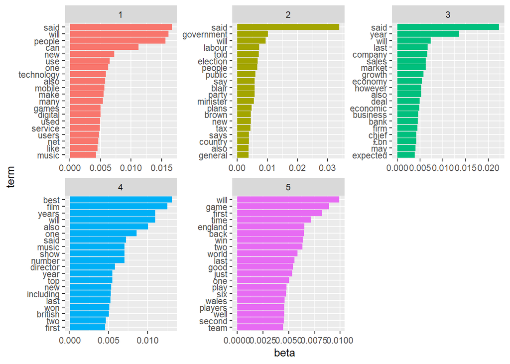

```r
lda_top_terms <- lda_topics %>%
  group_by(topic) %>%
  slice_max(beta, n = 20) %>% # We use dplyr’s slice_max() to find the top 10 terms within each topic.
  ungroup() %>%
  arrange(topic, -beta)

lda_top_terms %>%
  mutate(term = reorder_within(term, beta, topic)) %>%
  ggplot(aes(beta, term, fill = factor(topic))) +
  geom_col(show.legend = FALSE) +
  facet_wrap(~ topic, scales = "free") +
  scale_y_reordered()
```

**11. Use the code below to save the terms and topics in a wide format.**

```r
beta_wide <- lda_topics %>%
  mutate(topic = paste0("topic", topic)) %>%
  pivot_wider(names_from = topic, values_from = beta) %>%
  mutate(log_ratio21 = log2(topic2 / topic1)) %>%
  mutate(log_ratio31 = log2(topic3 / topic1))%>%
  mutate(log_ratio41 = log2(topic4 / topic1))%>%
  mutate(log_ratio51 = log2(topic5 / topic1))

head(beta_wide, 10)
```

```
# A tibble: 10 × 10
   term           topic1  topic2  topic3  topic4  topic5 log_ratio21 log_ratio31
   <chr>           <dbl>   <dbl>   <dbl>   <dbl>   <dbl>       <dbl>       <dbl>
 1 accounts    0.0000690 1.32e-6 1.23e-3 1.80e-6 1.54e-6      -5.70        4.15
 2 advert      0.000177  1.32e-6 1.52e-6 1.80e-6 1.54e-6      -7.07       -6.87
 3 advertising 0.000380  1.32e-6 2.29e-4 1.80e-6 1.54e-6      -8.17       -0.733
 4 alexander   0.0000149 1.32e-6 1.38e-4 3.44e-4 1.54e-6      -3.49        3.21
 5 already     0.00257   1.25e-3 5.77e-4 7.04e-4 1.09e-4      -1.05       -2.16
 6 also        0.00574   3.76e-3 5.23e-3 1.01e-2 2.02e-3      -0.610      -0.135
 7 amount      0.000543  1.32e-6 8.35e-4 1.28e-4 1.54e-6      -8.68        0.621
 8 analysts    0.000611  1.32e-6 2.58e-3 5.58e-5 1.54e-6      -8.85        2.08
 9 aol         0.000299  1.32e-6 1.52e-6 1.80e-6 1.54e-6      -7.82       -7.63
10 around      0.00270   2.53e-4 7.73e-5 1.55e-3 1.54e-6      -3.41       -5.12
# ℹ 2 more variables: log_ratio41 <dbl>, log_ratio51 <dbl>
```

**12. Use the log ratios to visualize the words with the greatest differences between topic 1 and other topics. Below you see this analysis for topics 1 and 2.**

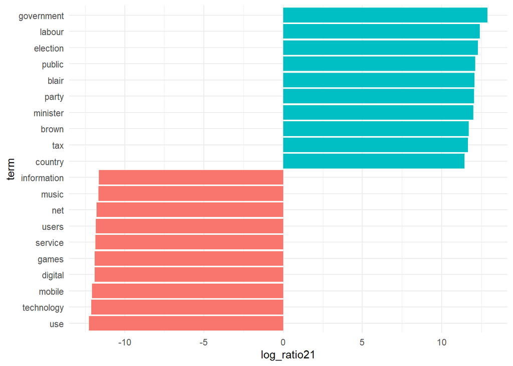

```r
# topic 1 versus topic 2
lda_top_terms1 <- beta_wide %>%
  slice_max(log_ratio21, n = 10) %>%
  arrange(term, -log_ratio21)

lda_top_terms2 <- beta_wide %>%
  slice_max(-log_ratio21, n = 10) %>%
  arrange(term, -log_ratio21)

lda_top_terms12 <- rbind(lda_top_terms1, lda_top_terms2)

# this is for ggplot to understand in which order to plot name on the x axis.
lda_top_terms12$term <- factor(lda_top_terms12$term, levels = lda_top_terms12$term[order(lda_top_terms12$log_ratio21)])

# Words with the greatest difference in beta between topic 2 and topic 1
lda_top_terms12 %>%
  ggplot(aes(log_ratio21, term, fill = (log_ratio21 > 0))) +
  geom_col(show.legend = FALSE) +
  scale_y_reordered() +
  theme_minimal()
```

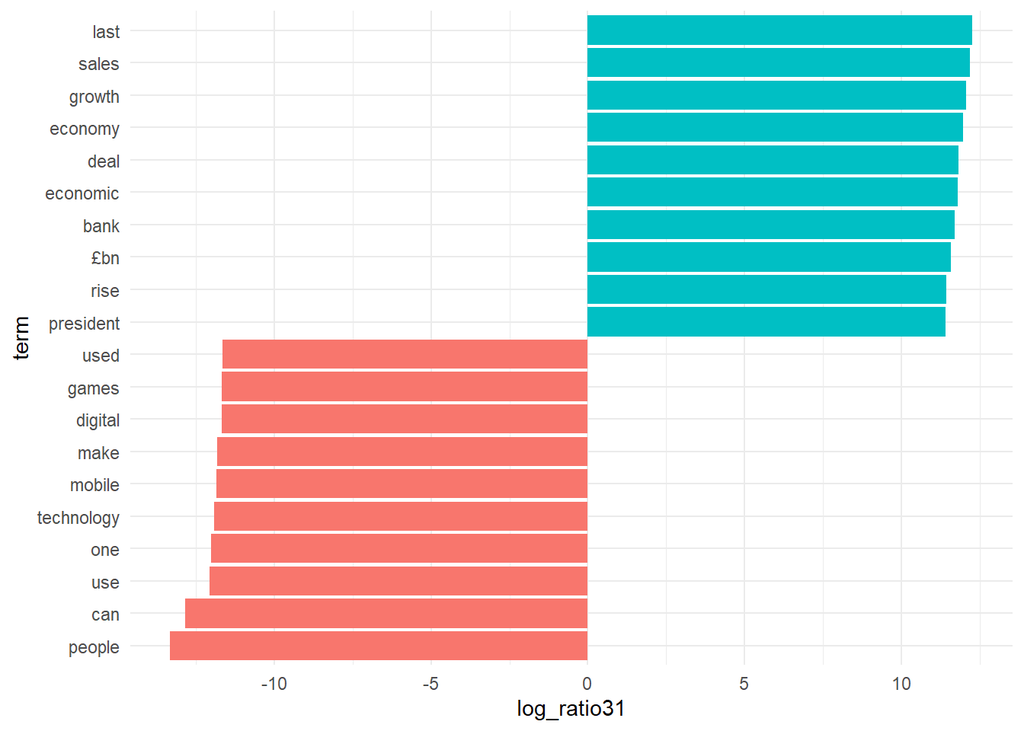

```r
# topic 1 versus topic 3
lda_top_terms1 <- beta_wide %>%
  slice_max(log_ratio31, n = 10) %>%
  arrange(term, -log_ratio31)

lda_top_terms3 <- beta_wide %>%
  slice_max(-log_ratio31, n = 10) %>%
  arrange(term, -log_ratio31)

lda_top_terms13 <- rbind(lda_top_terms1, lda_top_terms3)

# this is for ggplot to understand in which order to plot name on the x axis.
lda_top_terms13$term <- factor(lda_top_terms13$term, levels = lda_top_terms13$term[order(lda_top_terms13$log_ratio31)])

# Words with the greatest difference in beta between topic 2 and topic 1
lda_top_terms13 %>%
  ggplot(aes(log_ratio31, term, fill = (log_ratio31 > 0))) +
  geom_col(show.legend = FALSE) +
  scale_y_reordered() +
  theme_minimal()
```

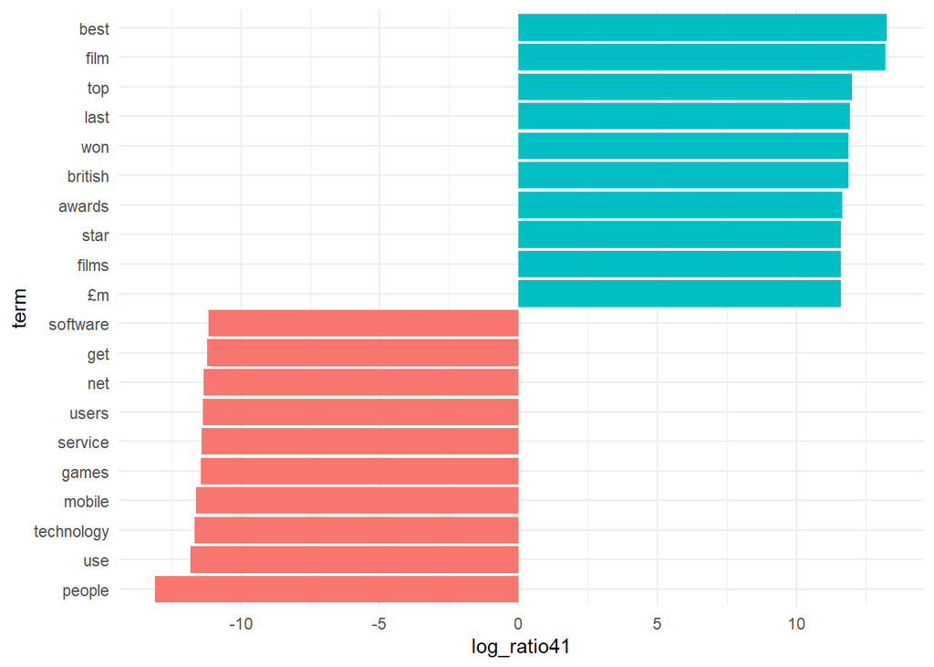

```r
# topic 1 versus topic 4
lda_top_terms1 <- beta_wide %>%
  slice_max(log_ratio41, n = 10) %>%
  arrange(term, -log_ratio41)

lda_top_terms4 <- beta_wide %>%
  slice_max(-log_ratio41, n = 10) %>%
  arrange(term, -log_ratio41)

lda_top_terms14 <- rbind(lda_top_terms1, lda_top_terms4)

# this is for ggplot to understand in which order to plot name on the x axis.
lda_top_terms14$term <- factor(lda_top_terms14$term, levels = lda_top_terms14$term[order(lda_top_terms14$log_ratio41)])

# Words with the greatest difference in beta between topic 2 and topic 1
lda_top_terms14 %>%
  ggplot(aes(log_ratio41, term, fill = (log_ratio41 > 0))) +
  geom_col(show.legend = FALSE) +
  scale_y_reordered() +
  theme_minimal()
```

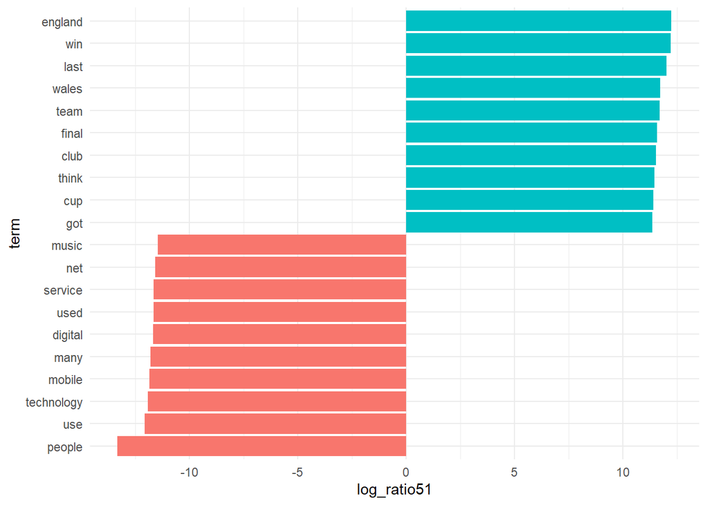

```r
# topic 1 versus topic 5
lda_top_terms1 <- beta_wide %>%
  slice_max(log_ratio51, n = 10) %>%
  arrange(term, -log_ratio51)

lda_top_terms5 <- beta_wide %>%
  slice_max(-log_ratio51, n = 10) %>%
  arrange(term, -log_ratio51)

lda_top_terms15 <- rbind(lda_top_terms1, lda_top_terms5)

# this is for ggplot to understand in which order to plot name on the x axis.
lda_top_terms15$term <- factor(lda_top_terms15$term, levels = lda_top_terms15$term[order(lda_top_terms15$log_ratio51)])

# Words with the greatest difference in beta between topic 2 and topic 1
lda_top_terms15 %>%
  ggplot(aes(log_ratio51, term, fill = (log_ratio51 > 0))) +
  geom_col(show.legend = FALSE) +
  scale_y_reordered() +
  theme_minimal()
```

**13. Besides estimating each topic as a mixture of words, LDA also models each document as a mixture of topics. We can examine the per-document-per-topic probabilities, called “gamma”, with the `matrix = "gamma"` argument in the `tidy()` function. Call this function for your LDA model and save the probabilities in a variable named lda_documents.**

```r
lda_documents <- tidy(lda_model, matrix = "gamma")
```

**14. Check the topic probabilities for documents with the index number of 1, 1000, 2000, 2225.**

```r
index_num <- c(1, 1000, 2000, 2225)
for (i in index_num){
  print(lda_documents[lda_documents$document == i,])
}
```

```
# A tibble: 5 × 3
  document topic  gamma
  <chr>    <int>  <dbl>
1 1            1 0.206
2 1            2 0.0623
3 1            3 0.584
4 1            4 0.0934
5 1            5 0.0545
# A tibble: 5 × 3
  document topic  gamma
  <chr>    <int>  <dbl>
1 1000         1 0.105
2 1000         2 0.307
3 1000         3 0.0674
4 1000         4 0.363
5 1000         5 0.157
# A tibble: 5 × 3
  document topic  gamma
  <chr>    <int>  <dbl>
1 2000         1 0.25
2 2000         2 0.224
3 2000         3 0.270
4 2000         4 0.173
5 2000         5 0.0816
# A tibble: 5 × 3
  document topic  gamma
  <chr>    <int>  <dbl>
1 2225         1 0.372
2 2225         2 0.140
3 2225         3 0.0467
4 2225         4 0.149
5 2225         5 0.292
```

**15. Use the code below to visualise the topic probabilities for the example documents in question 14.**

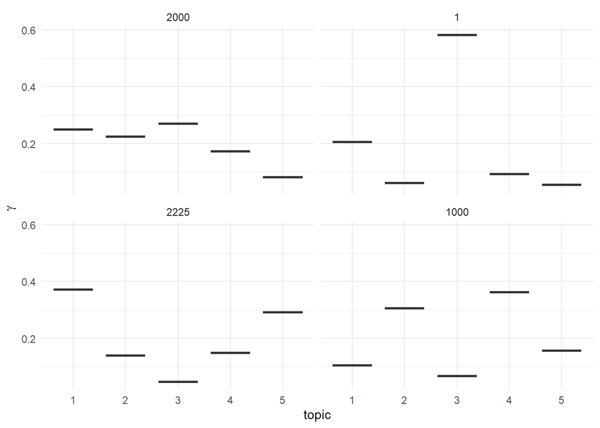

```r
# reorder titles in order of topic 1, topic 2, etc before plotting
lda_documents[lda_documents$document %in% c(1, 1000, 2000, 2225),] %>%
  mutate(document = reorder(document, gamma * topic)) %>%
  ggplot(aes(factor(topic), gamma)) +
  geom_boxplot() +
  facet_wrap(~ document) +
  labs(x = "topic", y = expression(gamma)) +
  theme_minimal()
```

# Alternative LDA implementations

The LDA() function in the topicmodels package is only one implementation of the latent Dirichlet allocation algorithm. For example, the mallet package (Mimno 2013) implements a wrapper around the MALLET Java package for text classification tools, and the tidytext package provides tidiers for this model output as well. The textmineR package has extensive functionality for topic modeling. You can fit Latent Dirichlet Allocation (LDA), Correlated Topic Models (CTM), and Latent Semantic Analysis (LSA) from within textmineR (https://cran.r-project.org/web/packages/textmineR/vignettes/c_topic_modeling.html).

```r
# library(mallet)
# library(textmineR)
```